# Examining Eelgrass Data

Noam Ross

February 17, 2015

[Grace Ha](http://www.researchgate.net/profile/Grace_Ha) kindly provided data on seagrass density and epiphytes to examine for underdispersion with the [cmp package](https://github.com/noamross/cmp), wich fits distributions to the [Conway-Maxell-Poisson] distribution. This is a quick spin through the data.

```r
library(cmp) #get with devtools::install_github('noamross/cmp') if needed
library(dplyr)
library(tidyr)
library(magrittr)
library(ggplot2)
library(knitr)
opts_chunk$set(cache=TRUE)
```

Let’s load and take a look at the data.

```r
ha_data = as.tbl(read.csv('../../data/Bodega-Harbor-Abundance-Data-02182015.csv'))
```

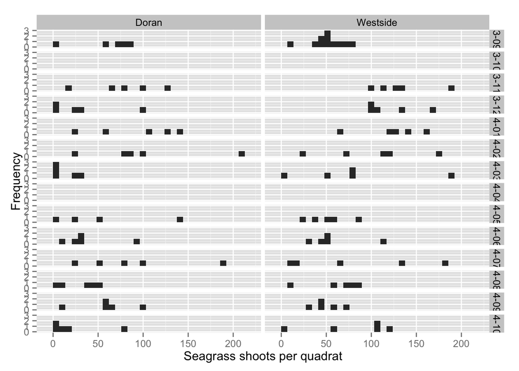

```r
seagrass_counts = ha_data %>%
  filter(site !="Channel") %>%
  mutate(date = as.Date(paste(year, substr(month,1,3), "01"), "%Y %b %d")) %>%
  select(date, site, quadrat, shootdensity) %>%
  distinct(date, site, quadrat)


ggplot(seagrass_counts, aes(x = shootdensity)) +
  geom_bar() +
  xlab("Seagrass shoots per quadrat") +
  theme(legend.position="none") +
  ylab("Frequency") +
  facet_grid(date~site)
```

```r
seagrass_stats = seagrass_counts %>%
  group_by(date, site) %>%
  summarize(mean_dens = mean(shootdensity), var_dens = var(shootdensity),
            var_mean_ratio = var_dens/mean_dens, samples = n()) %>%
  group_by() %>%
  arrange(site, date)
kable(seagrass_stats, digits = 2)
```

| date | site | mean_dens | var_dens | var_mean_ratio | samples |
| --- | --- | --- | --- | --- | --- |
| 2013-09-01 | Doran | 60.00 | 1232.00 | 20.53 | 5 |
| 2013-11-01 | Doran | 77.20 | 1794.20 | 23.24 | 5 |
| 2013-12-01 | Doran | 32.20 | 1576.70 | 48.97 | 5 |
| 2014-01-01 | Doran | 92.80 | 2476.20 | 26.68 | 5 |
| 2014-02-01 | Doran | 99.60 | 4330.30 | 43.48 | 5 |
| 2014-03-01 | Doran | 11.40 | 194.30 | 17.04 | 5 |
| 2014-04-01 | Doran | NA | NA | NA | 15 |
| 2014-05-01 | Doran | 53.50 | 3557.67 | 66.50 | 4 |
| 2014-06-01 | Doran | 38.00 | 1017.00 | 26.76 | 5 |
| 2014-07-01 | Doran | 88.80 | 4026.20 | 45.34 | 5 |
| 2014-08-01 | Doran | 30.40 | 467.80 | 15.39 | 5 |
| 2014-09-01 | Doran | 58.20 | 967.70 | 16.63 | 5 |
| 2014-10-01 | Doran | 23.20 | 977.70 | 42.14 | 5 |
| 2013-09-01 | Westside | 51.64 | 311.85 | 6.04 | 11 |
| 2013-10-01 | Westside | NA | NA | NA | 5 |
| 2013-11-01 | Westside | 131.40 | 1116.30 | 8.50 | 5 |
| 2013-12-01 | Westside | 121.20 | 921.70 | 7.60 | 5 |
| 2014-01-01 | Westside | 123.40 | 1288.80 | 10.44 | 5 |
| 2014-02-01 | Westside | 101.00 | 3237.00 | 32.05 | 5 |
| 2014-03-01 | Westside | 80.80 | 4875.70 | 60.34 | 5 |
| 2014-04-01 | Westside | NA | NA | NA | 15 |
| 2014-05-01 | Westside | 51.40 | 475.30 | 9.25 | 5 |
| 2014-06-01 | Westside | 57.60 | 901.30 | 15.65 | 5 |
| 2014-07-01 | Westside | 81.20 | 5571.70 | 68.62 | 5 |
| 2014-08-01 | Westside | 58.80 | 949.70 | 16.15 | 5 |
| 2014-09-01 | Westside | 50.00 | 245.50 | 4.91 | 5 |
| 2014-10-01 | Westside | 78.40 | 2209.30 | 28.18 | 5 |

OK, seagrass density is generally highly overdispersed - all the the variance/mean ratios are over 1. Let’s look at ratios for invertebrates on leaves:

```r
invert_counts = ha_data %>%
  mutate(date = as.Date(paste(year, substr(month,1,3), "01"), "%Y %b %d")) %>%
  gather("invert", "invert_count",  13:67)

invert_stats = invert_counts %>%
  group_by(invert) %>%
  summarize(samples = sum(!is.na(invert_count)),
            nonzeros = sum(na.omit(invert_count) > 0),
            mean_count = mean(invert_count, na.rm=TRUE),
            var_count = var(invert_count, na.rm=TRUE),
            var_mean_ratio = var_count/mean_count) %>%
  group_by() %>%
  arrange(var_mean_ratio)

kable(invert_stats)
```

| invert | samples | nonzeros | mean_count | var_count | var_mean_ratio |
| --- | --- | --- | --- | --- | --- |
| gammaridUN2 | 57 | 2 | 0.0350877 | 0.0344612 | 0.9821429 |
| cumaceaUN | 234 | 5 | 0.0213675 | 0.0210007 | 0.9828326 |
| mysidUN | 264 | 3 | 0.0113636 | 0.0112772 | 0.9923954 |
| egg.UNGR | 174 | 2 | 0.0114943 | 0.0114278 | 0.9942197 |
| egg.UNYR | 174 | 2 | 0.0114943 | 0.0114278 | 0.9942197 |
| crabUN | 353 | 3 | 0.0084986 | 0.0084503 | 0.9943182 |
| EPPR | 264 | 2 | 0.0075758 | 0.0075470 | 0.9961977 |
| jingleshellUN | 324 | 2 | 0.0061728 | 0.0061537 | 0.9969040 |
| tunicateUN | 356 | 2 | 0.0056180 | 0.0056022 | 0.9971831 |
| clamUN | 324 | 1 | 0.0030864 | 0.0030864 | 1.0000000 |
| egg.UN1 | 274 | 1 | 0.0036496 | 0.0036496 | 1.0000000 |
| HECR | 330 | 1 | 0.0030303 | 0.0030303 | 1.0000000 |
| scalewormUN | 264 | 1 | 0.0037879 | 0.0037879 | 1.0000000 |
| shrimpUN | 174 | 1 | 0.0057471 | 0.0057471 | 1.0000000 |
| polychaeteUN2 | 57 | 1 | 0.0175439 | 0.0175439 | 1.0000000 |
| nematodeUN | 12 | 1 | 0.0833333 | 0.0833333 | 1.0000000 |
| mollusc1 | 120 | 1 | 0.0083333 | 0.0083333 | 1.0000000 |
| hydroidUN | 184 | 1 | 0.0054348 | 0.0054348 | 1.0000000 |
| caprellidUN1 | 234 | 1 | 0.0042735 | 0.0042735 | 1.0000000 |
| flatwormUN1 | 324 | 6 | 0.0216049 | 0.0273956 | 1.2680230 |
| limpetUN | 324 | 5 | 0.0185185 | 0.0244238 | 1.3188854 |
| LISP | 335 | 9 | 0.0328358 | 0.0438288 | 1.3347850 |
| bryozoanUN | 294 | 3 | 0.0136054 | 0.0202921 | 1.4914676 |
| barnacleUN | 324 | 3 | 0.0123457 | 0.0184230 | 1.4922601 |
| cowrieUN | 264 | 5 | 0.0265152 | 0.0411194 | 1.5507876 |
| ALCA | 361 | 8 | 0.0332410 | 0.0600031 | 1.8050926 |
| nemerteanTE | 87 | 12 | 0.2298851 | 0.4581663 | 1.9930233 |
| LAspp | 361 | 129 | 0.6869806 | 1.4878578 | 2.1657930 |
| egg.HECR | 360 | 3 | 0.0138889 | 0.0304472 | 2.1922006 |
| polychaetePH | 234 | 18 | 0.1410256 | 0.3276659 | 2.3234491 |
| isopodUN1 | 57 | 2 | 0.0701754 | 0.1735589 | 2.4732143 |
| egg.PHTA | 360 | 6 | 0.0388889 | 0.1099041 | 2.8261043 |
| PHTA | 357 | 79 | 0.4313725 | 1.3864287 | 3.2139939 |
| ostracodUN | 204 | 3 | 0.0343137 | 0.1318217 | 3.8416608 |
| egg.LASP | 334 | 45 | 0.3173653 | 1.2503282 | 3.9397133 |
| spaghettiUN | 324 | 23 | 0.1913580 | 0.8239499 | 4.3058025 |
| nemerteanUN1 | 294 | 108 | 1.2210884 | 6.1045367 | 4.9992585 |
| musselUN | 324 | 25 | 0.1666667 | 0.9133127 | 5.4798762 |
| CLCA | 350 | 65 | 0.5600000 | 3.1812034 | 5.6807204 |
| AMLA | 234 | 19 | 0.2264957 | 1.3604967 | 6.0067212 |
| IDRE | 356 | 61 | 0.6657303 | 6.0992166 | 9.1616925 |
| TAspp | 264 | 46 | 0.5833333 | 5.3694550 | 9.2047800 |
| nemerteanUNGR | 87 | 42 | 2.4597701 | 24.9721999 | 10.1522495 |
| PLBI | 234 | 156 | 4.5085470 | 54.7917721 | 12.1528670 |
| gammaridUN1 | 350 | 150 | 1.9514286 | 29.2898977 | 15.0094644 |
| egg.UNWH | 334 | 48 | 1.7664671 | 48.8041575 | 27.6281163 |
| CACA | 350 | 171 | 4.3400000 | 133.8410888 | 30.8389606 |
| copepodUN | 332 | 91 | 7.2500000 | 454.3512085 | 62.6691322 |
| polychaeteUN1 | 350 | 115 | 6.8542857 | 488.3139501 | 71.2421353 |
| egg.UN2 | 37 | 0 | 0.0000000 | 0.0000000 | NaN |
| HEspp | 57 | 0 | 0.0000000 | 0.0000000 | NaN |
| HEOR | 57 | 0 | 0.0000000 | 0.0000000 | NaN |
| crustaceanUN2 | 60 | 0 | 0.0000000 | 0.0000000 | NaN |
| nemerteanUN2 | 42 | 0 | 0.0000000 | 0.0000000 | NaN |
| flatwormUN2 | 42 | 0 | 0.0000000 | 0.0000000 | NaN |

Most of the invertebrate counts are overdispersed, or have a variance/mean ratio very close to one. However, this is when we look at distributions across all sites and times. Let’s try breaking up by location and date. In this case, I’ll filter to only those that we have more than 1 observation, and look at only those cases where a species has at least on case where the ratio is less than one.

```r
invert_stats_2 = invert_counts %>%
  group_by(invert, date, site) %>%
    summarize(samples = sum(!is.na(invert_count)),
            nonzeros = sum(na.omit(invert_count) > 0),
            mean_count = mean(invert_count, na.rm=TRUE),
            var_count = var(invert_count, na.rm=TRUE),
            var_mean_ratio = var_count/mean_count) %>%
  group_by(invert, site) %>%
  mutate(mean_ratio = mean(var_mean_ratio, na.rm=TRUE)) %>%
  filter(nonzeros > 1) %>%
  filter(any(var_mean_ratio < 1)) %>%
  group_by() %>%
  arrange(mean_ratio, as.character(invert), site) %>%
  select(-mean_ratio)

kable(invert_stats_2, digits=2)
```

| invert | date | site | samples | nonzeros | mean_count | var_count | var_mean_ratio |
| --- | --- | --- | --- | --- | --- | --- | --- |
| CLCA | 2013-10-01 | Channel | 15 | 3 | 0.20 | 0.17 | 0.86 |
| PHTA | 2013-10-01 | Channel | 15 | 3 | 0.20 | 0.17 | 0.86 |
| mysidUN | 2013-12-01 | Doran | 15 | 3 | 0.20 | 0.17 | 0.86 |
| PHTA | 2013-09-01 | Doran | 15 | 6 | 0.47 | 0.41 | 0.88 |
| PHTA | 2013-11-01 | Doran | 15 | 8 | 0.67 | 0.52 | 0.79 |
| PHTA | 2013-12-01 | Doran | 15 | 9 | 0.80 | 0.60 | 0.75 |
| PHTA | 2014-07-01 | Doran | 15 | 4 | 0.33 | 0.38 | 1.14 |
| PHTA | 2014-09-01 | Doran | 6 | 3 | 0.67 | 0.67 | 1.00 |
| PHTA | 2014-10-01 | Doran | 6 | 2 | 0.33 | 0.27 | 0.80 |
| LISP | 2013-11-01 | Westside | 15 | 2 | 0.13 | 0.12 | 0.93 |
| egg.UNGR | 2014-03-01 | Doran | 15 | 2 | 0.13 | 0.12 | 0.93 |
| egg.UNYR | 2014-03-01 | Doran | 15 | 2 | 0.13 | 0.12 | 0.93 |
| jingleshellUN | 2013-10-01 | Channel | 15 | 2 | 0.13 | 0.12 | 0.93 |
| limpetUN | 2013-12-01 | Doran | 15 | 2 | 0.13 | 0.12 | 0.93 |
| nemerteanUNGR | 2014-06-01 | Westside | 15 | 3 | 0.20 | 0.17 | 0.86 |
| cumaceaUN | 2014-06-01 | Westside | 15 | 3 | 0.20 | 0.17 | 0.86 |
| LAspp | 2013-09-01 | Doran | 15 | 2 | 0.13 | 0.12 | 0.93 |
| LAspp | 2013-11-01 | Doran | 15 | 11 | 1.40 | 1.40 | 1.00 |
| LAspp | 2013-12-01 | Doran | 15 | 4 | 0.33 | 0.38 | 1.14 |
| LAspp | 2014-02-01 | Doran | 15 | 5 | 0.40 | 0.40 | 1.00 |
| LAspp | 2014-03-01 | Doran | 15 | 7 | 0.73 | 0.78 | 1.06 |
| LAspp | 2014-04-01 | Doran | 15 | 3 | 0.27 | 0.35 | 1.32 |
| LAspp | 2014-06-01 | Doran | 15 | 5 | 0.47 | 0.70 | 1.49 |
| LAspp | 2014-10-01 | Doran | 10 | 2 | 0.20 | 0.18 | 0.89 |
| flatwormUN1 | 2013-11-01 | Westside | 15 | 2 | 0.13 | 0.12 | 0.93 |
| CLCA | 2013-09-01 | Doran | 15 | 9 | 1.93 | 6.35 | 3.29 |
| CLCA | 2013-11-01 | Doran | 15 | 4 | 0.27 | 0.21 | 0.79 |
| CLCA | 2013-12-01 | Doran | 15 | 6 | 0.40 | 0.26 | 0.64 |
| CLCA | 2014-01-01 | Doran | 15 | 2 | 0.13 | 0.12 | 0.93 |
| CLCA | 2014-04-01 | Doran | 15 | 2 | 0.13 | 0.12 | 0.93 |

[output cut: 77 more lines]

So this table summarizes invertebrate/site/date combinations at the plot level, showing only those cases where at least one of the invertebrate/site combination has a variance/mean ratio of less than one. For the most part, it’s hard to see anything that is consistently underdispersed.

But we don’t need to guess! I’m going to use my `cmp` package to fit a distribution to each of these

```r
invert_fits = invert_counts %>%
  filter(!is.na(invert_count)) %>%
  group_by(invert, date, site) %>%
  filter(any(invert_count > 0)) %>%
  do({
    invert_dist = table(.$invert_count)
    invert_dist = cbind(as.numeric(names(invert_dist)), invert_dist)
    cmp = cmp_fit(invert_dist)
    pois = pois_fit(invert_dist)
    nb = nb_fit(invert_dist)
    data_frame(samples = sum(!is.na(.$invert_count)),
            nonzeros = sum(na.omit(.$invert_count) > 0),
            mean_count = mean(.$invert_count, na.rm=TRUE),
            var_count = var(.$invert_count, na.rm=TRUE),
            var_mean_ratio = var(.$invert_count, na.rm=TRUE)/mean(.$invert_count, na.rm=TRUE),
            cmp_lambda = cmp$lambda, cmp_nu = cmp$nu, cmp_ll = cmp$log.likelihood,
               pois_lambda = pois$lambda, pois_ll = pois$log.likelihood,
               nb_mu = nb$mu, nb_size = nb$size, nb_ll = nb$log.likelihood)
  }) %>%
  group_by() %>%
  arrange(desc(cmp_nu))

kable(invert_fits)
```

| invert | date | site | samples | nonzeros | mean_count | var_count | var_mean_ratio | cmp_lambda | cmp_nu | cmp_ll | pois_lambda | pois_ll | nb_mu | nb_size | nb_ll |
| --- | --- | --- | --- | --- | --- | --- | --- | --- | --- | --- | --- | --- | --- | --- | --- |
| PHTA | 2014-10-01 | Westside | 1 | 1 | 1.0000000 | NA | NA | 1.673783e+17 | 7.380136e+22 | 0.000000 | 1.0000000 | -1.000000 | 0.9999526 | 5.882224e+07 | -1.000000 |
| CLCA | 2013-12-01 | Doran | 15 | 6 | 0.4000000 | 0.2571429 | 0.6428571 | 6.666113e-01 | 5.256036e+02 | -10.095175 | 0.4000000 | -11.497744 | 0.4000337 | 9.440211e+06 | -11.497744 |
| PHTA | 2014-08-01 | Westside | 6 | 2 | 0.3333333 | 0.2666667 | 0.8000000 | 5.000688e-01 | 3.725646e+02 | -3.819085 | 0.3333333 | -4.197225 | 0.3333614 | 9.440211e+06 | -4.197225 |
| PHTA | 2014-10-01 | Doran | 6 | 2 | 0.3333333 | 0.2666667 | 0.8000000 | 5.000688e-01 | 3.725646e+02 | -3.819085 | 0.3333333 | -4.197225 | 0.3333614 | 9.440211e+06 | -4.197225 |
| LAspp | 2014-01-01 | Westside | 15 | 5 | 0.3333333 | 0.2380952 | 0.7142857 | 5.000688e-01 | 3.725646e+02 | -9.547713 | 0.3333333 | -10.493061 | 0.3333614 | 9.440211e+06 | -10.493061 |
| gammaridUN1 | 2014-08-01 | Doran | 9 | 3 | 0.3333333 | 0.2500000 | 0.7500000 | 5.000688e-01 | 3.725646e+02 | -5.728627 | 0.3333333 | -6.295837 | 0.3333614 | 9.440211e+06 | -6.295837 |
| gammaridUN1 | 2014-09-01 | Doran | 6 | 2 | 0.3333333 | 0.2666667 | 0.8000000 | 5.000688e-01 | 3.725646e+02 | -3.819085 | 0.3333333 | -4.197225 | 0.3333614 | 9.440211e+06 | -4.197225 |
| egg.LASP | 2014-01-01 | Westside | 15 | 1 | 0.0666667 | 0.0666667 | 1.0000000 | 7.141470e-02 | 4.020810e+01 | -3.673950 | 0.0666667 | -3.708050 | 0.0666667 | 3.981072e+06 | -3.708050 |
| egg.UNWH | 2013-11-01 | Doran | 15 | 1 | 0.0666667 | 0.0666667 | 1.0000000 | 7.141470e-02 | 4.020810e+01 | -3.673950 | 0.0666667 | -3.708050 | 0.0666667 | 3.981072e+06 | -3.708050 |
| egg.UNWH | 2014-02-01 | Doran | 15 | 1 | 0.0666667 | 0.0666667 | 1.0000000 | 7.141470e-02 | 4.020810e+01 | -3.673950 | 0.0666667 | -3.708050 | 0.0666667 | 3.981072e+06 | -3.708050 |
| egg.UN1 | 2013-12-01 | Doran | 15 | 1 | 0.0666667 | 0.0666667 | 1.0000000 | 7.141470e-02 | 4.020810e+01 | -3.673950 | 0.0666667 | -3.708050 | 0.0666667 | 3.981072e+06 | -3.708050 |
| hydroidUN | 2014-03-01 | Westside | 15 | 1 | 0.0666667 | 0.0666667 | 1.0000000 | 7.141470e-02 | 4.020810e+01 | -3.673950 | 0.0666667 | -3.708050 | 0.0666667 | 3.981072e+06 | -3.708050 |
| PHTA | 2014-01-01 | Doran | 15 | 1 | 0.0666667 | 0.0666667 | 1.0000000 | 7.141470e-02 | 4.020810e+01 | -3.673950 | 0.0666667 | -3.708050 | 0.0666667 | 3.981072e+06 | -3.708050 |
| LISP | 2013-10-01 | Channel | 15 | 1 | 0.0666667 | 0.0666667 | 1.0000000 | 7.141470e-02 | 4.020810e+01 | -3.673950 | 0.0666667 | -3.708050 | 0.0666667 | 3.981072e+06 | -3.708050 |
| LISP | 2013-11-01 | Doran | 15 | 1 | 0.0666667 | 0.0666667 | 1.0000000 | 7.141470e-02 | 4.020810e+01 | -3.673950 | 0.0666667 | -3.708050 | 0.0666667 | 3.981072e+06 | -3.708050 |
| ALCA | 2013-12-01 | Doran | 15 | 1 | 0.0666667 | 0.0666667 | 1.0000000 | 7.141470e-02 | 4.020810e+01 | -3.673950 | 0.0666667 | -3.708050 | 0.0666667 | 3.981072e+06 | -3.708050 |
| ALCA | 2014-01-01 | Westside | 15 | 1 | 0.0666667 | 0.0666667 | 1.0000000 | 7.141470e-02 | 4.020810e+01 | -3.673950 | 0.0666667 | -3.708050 | 0.0666667 | 3.981072e+06 | -3.708050 |
| ALCA | 2014-05-01 | Westside | 15 | 1 | 0.0666667 | 0.0666667 | 1.0000000 | 7.141470e-02 | 4.020810e+01 | -3.673950 | 0.0666667 | -3.708050 | 0.0666667 | 3.981072e+06 | -3.708050 |
| HECR | 2013-10-01 | Westside | 15 | 1 | 0.0666667 | 0.0666667 | 1.0000000 | 7.141470e-02 | 4.020810e+01 | -3.673950 | 0.0666667 | -3.708050 | 0.0666667 | 3.981072e+06 | -3.708050 |
| mollusc1 | 2014-05-01 | Westside | 15 | 1 | 0.0666667 | 0.0666667 | 1.0000000 | 7.141470e-02 | 4.020810e+01 | -3.673950 | 0.0666667 | -3.708050 | 0.0666667 | 3.981072e+06 | -3.708050 |
| IDRE | 2013-12-01 | Doran | 15 | 1 | 0.0666667 | 0.0666667 | 1.0000000 | 7.141470e-02 | 4.020810e+01 | -3.673950 | 0.0666667 | -3.708050 | 0.0666667 | 3.981072e+06 | -3.708050 |
| TAspp | 2013-12-01 | Westside | 15 | 1 | 0.0666667 | 0.0666667 | 1.0000000 | 7.141470e-02 | 4.020810e+01 | -3.673950 | 0.0666667 | -3.708050 | 0.0666667 | 3.981072e+06 | -3.708050 |
| TAspp | 2014-04-01 | Westside | 15 | 1 | 0.0666667 | 0.0666667 | 1.0000000 | 7.141470e-02 | 4.020810e+01 | -3.673950 | 0.0666667 | -3.708050 | 0.0666667 | 3.981072e+06 | -3.708050 |
| TAspp | 2014-06-01 | Westside | 15 | 1 | 0.0666667 | 0.0666667 | 1.0000000 | 7.141470e-02 | 4.020810e+01 | -3.673950 | 0.0666667 | -3.708050 | 0.0666667 | 3.981072e+06 | -3.708050 |
| CACA | 2014-01-01 | Doran | 15 | 1 | 0.0666667 | 0.0666667 | 1.0000000 | 7.141470e-02 | 4.020810e+01 | -3.673950 | 0.0666667 | -3.708050 | 0.0666667 | 3.981072e+06 | -3.708050 |
| CACA | 2014-02-01 | Westside | 15 | 1 | 0.0666667 | 0.0666667 | 1.0000000 | 7.141470e-02 | 4.020810e+01 | -3.673950 | 0.0666667 | -3.708050 | 0.0666667 | 3.981072e+06 | -3.708050 |
| caprellidUN1 | 2014-03-01 | Doran | 15 | 1 | 0.0666667 | 0.0666667 | 1.0000000 | 7.141470e-02 | 4.020810e+01 | -3.673950 | 0.0666667 | -3.708050 | 0.0666667 | 3.981072e+06 | -3.708050 |
| AMLA | 2014-02-01 | Westside | 15 | 1 | 0.0666667 | 0.0666667 | 1.0000000 | 7.141470e-02 | 4.020810e+01 | -3.673950 | 0.0666667 | -3.708050 | 0.0666667 | 3.981072e+06 | -3.708050 |
| gammaridUN1 | 2014-02-01 | Doran | 15 | 1 | 0.0666667 | 0.0666667 | 1.0000000 | 7.141470e-02 | 4.020810e+01 | -3.673950 | 0.0666667 | -3.708050 | 0.0666667 | 3.981072e+06 | -3.708050 |
| gammaridUN1 | 2014-06-01 | Doran | 15 | 1 | 0.0666667 | 0.0666667 | 1.0000000 | 7.141470e-02 | 4.020810e+01 | -3.673950 | 0.0666667 | -3.708050 | 0.0666667 | 3.981072e+06 | -3.708050 |

[output cut: 287 more lines]